# Geog533 Lab 8

Amber Jacobson

Complete the following exercises in Chapter 8 (Introduction to Regression Analysis) of the textbook [R] pages 247-250.

## Question 1

This is Exercise 1 in Chapter 8 of the Textbook [R].

A regression of weekly shopping trip frequency on annual income (data entered in thousands of dollars) is performed on data collected from 24 respondents. The results are summarized below:

- Intercept: 0.46
- Slope: 0.19

|  | Sum of squares | Degrees of freedom | Mean square | *F* |
| --- | --- | --- | --- | --- |
| Regression |  |  |  |  |
| Residual | 1.7 |  |  |  |
| Total | 2.3 |  |  |  |

### Question 1(a)

Fill in the blanks in the ANOVA table.

```r
n <- 24
independent <- 1
regression <- 2.3 - 1.7
regression
```

```
[1] 0.6
```

```r
num <- independent
den <- n - 2
ms1 <- regression/num
res <- 1.7
ms2 <- res/den
fstat <- ms1/ms2
```

|  | Sum of squares | Degrees of freedom | Mean square | *F* |
| --- | --- | --- | --- | --- |
| Regression | 0.6 | 1 | 0.6 | 7.7647059 |
| Residual | 1.7 | 22 | 0.0772727 |  |
| Total | 2.3 |  |  |  |

### Question 1(b)

What is the predicted number of weekly shopping trips for someone making $50,000/year?

```r
a <- .46
b <- .19
x <- 50
y <- a + (b*x)
y
```

```
[1] 9.96
```

### Question 1(d)

Is the regression coefficient significantly different from zero? How do you know?

```r
fcrit <- qf(.975, df1 = 1, df2 = 22)
fvalue <- fstat
if(fvalue>fcrit){
  print("We reject the null hypothesis")
} else {
  print("We cannot reject the null hypothesis")
}
```

```
[1] "We reject the null hypothesis"
```

### Question 1(e)

What is the value of the correlation coefficient?

```r
total <- 2.3
r2 <- regression/total
r <- sqrt(r2)
r
```

```
[1] 0.5107539
```

## Question 2

This is Exercise 6 in Chapter 8 of the Textbook [R].

The following data are collected in an effort to determine whether snowfall is dependent upon elevation:

| Snowfall (inches) | Elevation (feet) |
| --- | --- |
| 36 | 400 |
| 78 | 800 |
| 11 | 200 |
| 45 | 675 |

Using R, show your work on exercises (a) through (g).

### Question 2(a)

Find the regression coefficients (the intercept and the slope coefficient).

```r
snowfall <- c(36, 78, 11, 45)
elevation <- c(400, 800, 200, 675)
df <- data.frame(snowfall, elevation)
m <- lm(snowfall ~ elevation, data = df)
summary(m)
```

```
Call:
lm(formula = snowfall ~ elevation, data = df)

Residuals:
       1        2        3        4
  4.9772   8.3172  -0.6928 -12.6016

Coefficients:
            Estimate Std. Error t value Pr(>|t|)
(Intercept) -7.63721   13.67764  -0.558   0.6328
elevation    0.09665    0.02403   4.022   0.0566 .
---
Signif. codes:  0 ‘***’ 0.001 ‘**’ 0.01 ‘*’ 0.05 ‘.’ 0.1 ‘ ’ 1

Residual standard error: 11.25 on 2 degrees of freedom
Multiple R-squared:  0.8899,    Adjusted R-squared:  0.8349
F-statistic: 16.17 on 1 and 2 DF,  p-value: 0.05663
```

```r
intercept <- -7.64
slope <- .097
intercept
```

```
[1] -7.64
```

```r
slope
```

```
[1] 0.097
```

### Question 2(b)

Estimate the standard error of the residuals about the regression line.

```r
anova(m)
```

```
Analysis of Variance Table

Response: snowfall
          Df  Sum Sq Mean Sq F value  Pr(>F)
elevation  1 2047.77 2047.77  16.173 0.05663 .
Residuals  2  253.23  126.61
---
Signif. codes:  0 ‘***’ 0.001 ‘**’ 0.01 ‘*’ 0.05 ‘.’ 0.1 ‘ ’ 1
```

```r
resmsq <- 126.61
s.error <- sqrt(resmsq)
s.error
```

```
[1] 11.25211
```

### Question 2(c)

```r
fcrit2 <- qf(.95, df1=1, df2= 2)
fvalue2 <- 16.173
if(fvalue2>fcrit2){
  print("We reject the null hypothesis")
} else {
  print("We cannot reject the null hypothesis")
}
```

```
[1] "We cannot reject the null hypothesis"
```

### Question 2(d)

Find the value of $r^2$.

```r
result <- cor.test(snowfall, elevation,method = "pearson")
result
```

```
    Pearson's product-moment correlation

data:  snowfall and elevation
t = 4.0216, df = 2, p-value = 0.05663
alternative hypothesis: true correlation is not equal to 0
95 percent confidence interval:
 -0.1898043  0.9988443
sample estimates:
      cor
0.9433711
```

```r
r <- result$estimate
r2 <- r^2
round(r2,4)
```

```
   cor
0.8899
```

### Question 2(e)

Make a table of the observed values, predicted values, and the residuals.

```r
snowfall <- c(36, 78, 11, 45)
elevation <- c(400, 800, 200, 675)
df <- data.frame(snowfall, elevation)
df$res <- m$residuals
df$predicted <- m$fitted.values
print(df)
```

| snowfall | elevation | res | predicted |
| --- | --- | --- | --- |
| 36 | 400 | 4.9771917 | 31.02281 |
| 78 | 800 | 8.3171775 | 69.68282 |
| 11 | 200 | -0.6928011 | 11.69280 |
| 45 | 675 | -12.6015681 | 57.60157 |

### Question 2(f)

Prepare an analysis of variance table portraying the regression results.

```r
n <- 4
regsum <- 2047.77
ressum <- 253.23
total <- regsum + ressum
regdf <- 1
resdf <- n - 2
msreg <- regsum/regdf
msred <- ressum/resdf
fstat2 <- msreg/msred
```

|  | Sum of squares | Degrees of freedom | Mean square | *F* |
| --- | --- | --- | --- | --- |
| Regression | 2047.77 | 1 | 2047.77 | 16.1732022 |
| Residual | 253.23 | 2 | 126.615 |  |
| Total | 2301 |  |  |  |

### Question 2(g)

Graph the data and the regression line.

```r
plot(df$elevation, df$snowfall)
abline(m,col="red",lwd=2)
```

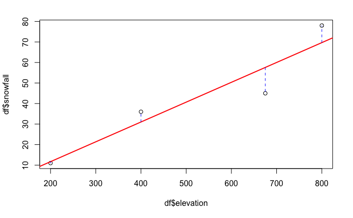

```r
segments(df$elevation,fitted(m),df$elevation,df$snowfall,col="blue",lty = "dashed")
```